# Assignment 3

Author

Vicki Shen

```r
library(tidyverse)
library(tidytext)
library(ggplot2)
library(textdata)
library(knitr)
library(kableExtra)
```

```r
pubmed <- read.csv("~/Downloads/pubmed.csv")
```

# Text Mining

## Question 1

```r
# How many abstracts are associated with each search term?
pubmed |>
  count (term, sort = TRUE) |>
  kable(col.names = c("Term", "Number of Abstracts"),
        caption = "Number of Abtracts with Each Search Term")
```

Number of Abtracts with Each Search Term

| Term | Number of Abstracts |
| --- | --- |
| covid | 981 |
| prostate cancer | 787 |
| preeclampsia | 780 |
| cystic fibrosis | 376 |
| meningitis | 317 |

```r
# Tokenize the abstracts and count the number of each token
tokens <- pubmed |>
  unnest_tokens(token, abstract)

token_counts <- tokens |>
  count(term, token, sort = TRUE)

# 5 most common tokens for each search term
top5 <- token_counts |>
  group_by(term) |>
  slice_max(order_by = n, n = 5)

top5 |>
  kable(col.names = c("Term", "Token", "Count"),
        caption = "Top 5 Most Common Tokens Per Search Term")
```

Top 5 Most Common Tokens Per Search Term

| Term | Token | Count |
| --- | --- | --- |
| covid | the | 9741 |
| covid | of | 7668 |
| covid | covid | 7275 |
| covid | 19 | 7035 |
| covid | and | 6861 |
| cystic fibrosis | the | 2677 |
| cystic fibrosis | of | 2304 |
| cystic fibrosis | and | 1777 |
| cystic fibrosis | in | 1497 |
| cystic fibrosis | to | 1011 |
| meningitis | the | 2489 |
| meningitis | of | 2269 |
| meningitis | and | 1683 |
| meningitis | in | 1322 |
| meningitis | a | 830 |
| preeclampsia | the | 7119 |
| preeclampsia | of | 6837 |
| preeclampsia | and | 5255 |
| preeclampsia | in | 3869 |
| preeclampsia | to | 2651 |
| prostate cancer | the | 6100 |
| prostate cancer | of | 5682 |
| prostate cancer | and | 4417 |
| prostate cancer | cancer | 3840 |
| prostate cancer | prostate | 3832 |

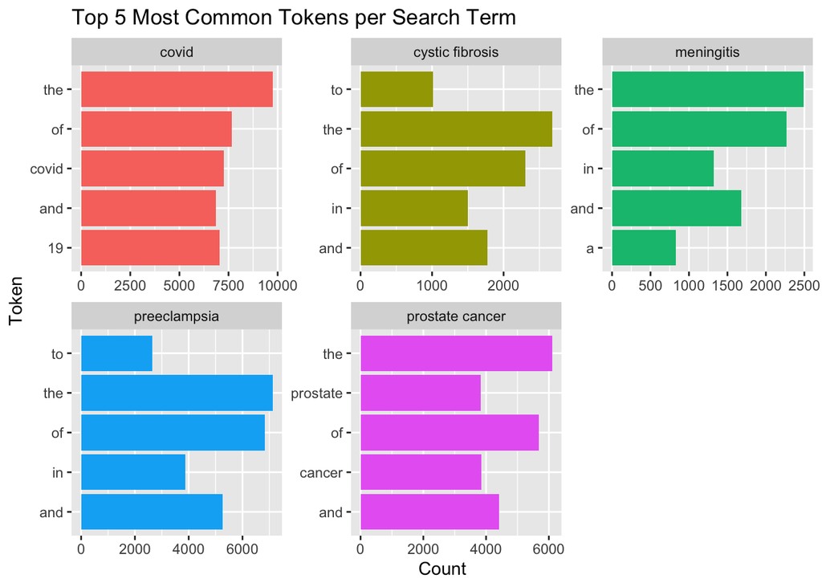

```r
# Visualization
top5 |>
  ggplot(aes(token, n, fill = term)) +
  geom_col(show.legend = FALSE) +
  facet_wrap(~term, scales = "free") +
  coord_flip() +
  scale_x_reordered() +
  labs(title = "Top 5 Most Common Tokens per Search Term",
       x = "Token",
       y = "Count")
```

*Observations*: For all of the search terms, the most common tokens were stop words such as “the”, “and”, “of”, “in”, and “to”. Although, there were only two terms, “prostate cancer” and “covid” that have meaningful words appearing in the top few (e.g., “prostate”, “cancer”, “covid”, “19”). Overall, the strong presence of stop words is not adding important insight and need to be filtered out in order to have a better idea of which tokens are utilized often in the abstracts.

## Question 2

```r
# Remove stop words
data("stop_words")

tokens_clean <- pubmed |>
  unnest_tokens(word, abstract) |>
  anti_join(stop_words, by = "word")

# Count what most frequent tokens appear
token_count_clean <- tokens_clean |>
  count(term, word, sort = TRUE)

# 5 most common tokens for each search term after removing stop words
top5_clean <- token_count_clean |>
  group_by(term) |>
  slice_max(order_by = n, n = 5)

top5_clean |>
  kable(col.names = c("Term", "Word", "Count"),
        caption = "Top 5 Most Common Tokens (After Removing Stop Words)")
```

Top 5 Most Common Tokens (After Removing Stop Words)

| Term | Word | Count |
| --- | --- | --- |
| covid | covid | 7275 |
| covid | 19 | 7035 |
| covid | patients | 2293 |
| covid | disease | 943 |
| covid | pandemic | 800 |
| cystic fibrosis | fibrosis | 867 |
| cystic fibrosis | cystic | 862 |
| cystic fibrosis | cf | 625 |
| cystic fibrosis | patients | 586 |
| cystic fibrosis | disease | 400 |
| meningitis | patients | 446 |
| meningitis | meningitis | 429 |
| meningitis | meningeal | 219 |
| meningitis | csf | 206 |
| meningitis | clinical | 187 |
| preeclampsia | pre | 2038 |
| preeclampsia | eclampsia | 2005 |
| preeclampsia | preeclampsia | 1863 |
| preeclampsia | women | 1196 |
| preeclampsia | pregnancy | 969 |
| prostate cancer | cancer | 3840 |
| prostate cancer | prostate | 3832 |
| prostate cancer | patients | 934 |
| prostate cancer | treatment | 926 |
| prostate cancer | disease | 652 |

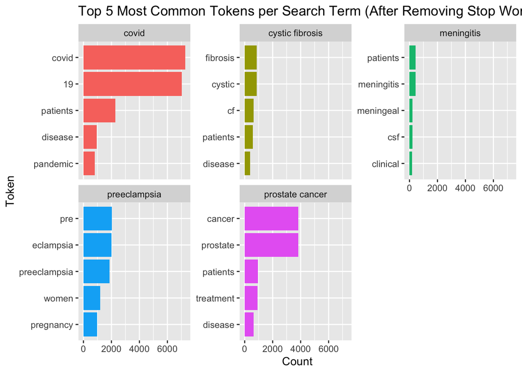

```r
# Visualization
top5_clean |>
  mutate(word = reorder_within(word, n, term)) |>
  ggplot(aes(word, n, fill = term)) +
  geom_col(show.legend = FALSE) +
  facet_wrap(~ term, scales = "free_y") +
  scale_x_reordered() +
  coord_flip() +
  labs(title = "Top 5 Most Common Tokens per Search Term (After Removing Stop Words)",
       x = "Token",
       y = "Count")
```

*Observations*: After removing stop words, the most common tokens change from filler words to more meaningful, topic-specific words. Each search term now has distinct vocabulary relevant to its focus area. For example, “pandemic”, “patients”, “disease,”covid-19” for *covid* and “treatment”, “prostate”, “disease”, “patients”, for *prostate cancer*. These tokens more accurately represent the thematic focus of each group of abstracts.

## Question 3

```r
# Tokenize abstracts into bigrams
bigram <- pubmed |>
  unnest_tokens(bigram, abstract, token = "ngrams", n = 2)

# Find 10 most common bigrams and visualize them
bigram_counts <- bigram |>
  count(bigram, sort = TRUE)

bigram_counts |>
  slice(1:10) |>
  kable(col.names = c("Bigram", "Count"),
        caption = "Top 10 Common Bigrams Per Search Term")
```

| Bigram | Count |
| --- | --- |
| covid 19 | 6969 |
| of the | 3883 |
| in the | 3418 |
| prostate cancer | 3222 |
| pre eclampsia | 1854 |
| patients with | 1587 |
| of covid | 1519 |
| and the | 1154 |
| to the | 1061 |
| of prostate | 870 |

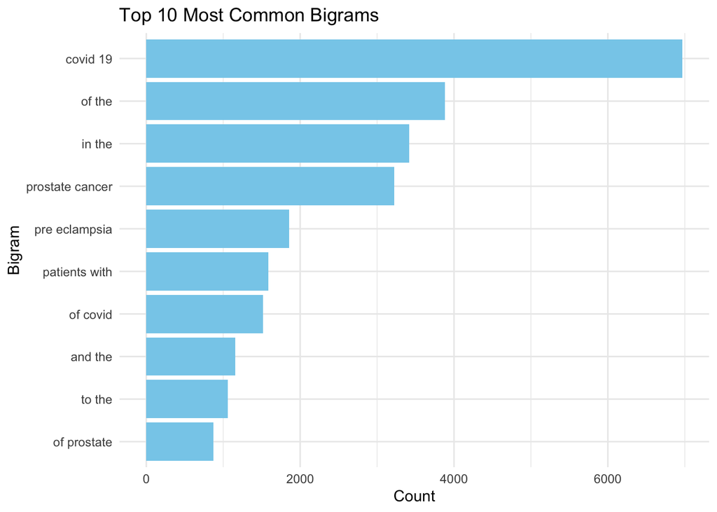

```r
bigram_counts |>
  slice_max(order_by = n, n = 10) |>
  mutate(bigram = fct_reorder(bigram, n)) |>
  ggplot(aes(x = bigram, y = n)) +
  geom_col(fill = "skyblue") +
  coord_flip() +
  labs(title = "Top 10 Most Common Bigrams",
       x = "Bigram",
       y = "Count") +
  theme_minimal()
```

*Observations*: The most common bigram is “covid 19”, which suggests that a huge portion of the abstracts in this data set focused their research on this disease. Other relevant common bigrams include “prostate cancer” and “pre eclampsia” which reflects the other search terms in this data set. Several bigrams, including “of the”, “in the”, “and the”, and “to the” are common stop-word combinations that occur in natural language but do not carry much meaning. However, there are a few words used in scientific writing (“patients with” and “of covid”) that showed up on the bar plot which does help in narrowing the domain the abstracts are associated with.

## Question 4

```r
# Calculate the TF-IDF value for each word-search term combination
tfidf <- tokens_clean |>
  count(term, word, sort = TRUE) |>
  bind_tf_idf(word, term, n) |>
  arrange(desc(tf_idf))

# 5 tokens from each search term with the highest TF-IDF value
top5_tfidf <- tfidf |>
  group_by(term) |>
  slice_max(order_by = tf_idf, n = 5) |>
  ungroup()

top5_tfidf |>
  kable(col.names = c("Term", "Word", "Count", "TF", "IDF", "TF-IDF"),
        caption = "Top 5 Tokens from Each Search Term by TF-IDF")
```

Top 5 Tokens from Each Search Term by TF-IDF

| Term | Word | Count | TF | IDF | TF-IDF |
| --- | --- | --- | --- | --- | --- |
| covid | covid | 7275 | 0.0646920 | 1.6094379 | 0.1041177 |
| covid | pandemic | 800 | 0.0071139 | 1.6094379 | 0.0114494 |
| covid | coronavirus | 647 | 0.0057534 | 1.6094379 | 0.0092597 |
| covid | sars | 372 | 0.0033080 | 1.6094379 | 0.0053240 |
| covid | cov | 334 | 0.0029701 | 1.6094379 | 0.0047801 |
| cystic fibrosis | cf | 625 | 0.0234126 | 0.9162907 | 0.0214528 |
| cystic fibrosis | fibrosis | 867 | 0.0324780 | 0.5108256 | 0.0165906 |
| cystic fibrosis | cystic | 862 | 0.0322907 | 0.5108256 | 0.0164949 |
| cystic fibrosis | cftr | 86 | 0.0032216 | 1.6094379 | 0.0051849 |
| cystic fibrosis | sweat | 83 | 0.0031092 | 1.6094379 | 0.0050041 |
| meningitis | meningitis | 429 | 0.0163959 | 1.6094379 | 0.0263883 |
| meningitis | meningeal | 219 | 0.0083700 | 1.6094379 | 0.0134709 |
| meningitis | pachymeningitis | 149 | 0.0056946 | 1.6094379 | 0.0091652 |
| meningitis | csf | 206 | 0.0078731 | 0.9162907 | 0.0072141 |
| meningitis | meninges | 106 | 0.0040512 | 1.6094379 | 0.0065202 |
| preeclampsia | eclampsia | 2005 | 0.0255268 | 1.6094379 | 0.0410837 |
| preeclampsia | preeclampsia | 1863 | 0.0237189 | 1.6094379 | 0.0381741 |
| preeclampsia | pregnancy | 969 | 0.0123369 | 0.5108256 | 0.0063020 |
| preeclampsia | maternal | 797 | 0.0101470 | 0.5108256 | 0.0051834 |
| preeclampsia | gestational | 191 | 0.0024317 | 1.6094379 | 0.0039137 |
| prostate cancer | prostate | 3832 | 0.0562950 | 1.6094379 | 0.0906033 |
| prostate cancer | androgen | 305 | 0.0044807 | 1.6094379 | 0.0072114 |
| prostate cancer | psa | 282 | 0.0041428 | 1.6094379 | 0.0066676 |
| prostate cancer | prostatectomy | 215 | 0.0031585 | 1.6094379 | 0.0050834 |
| prostate cancer | castration | 148 | 0.0021742 | 1.6094379 | 0.0034993 |

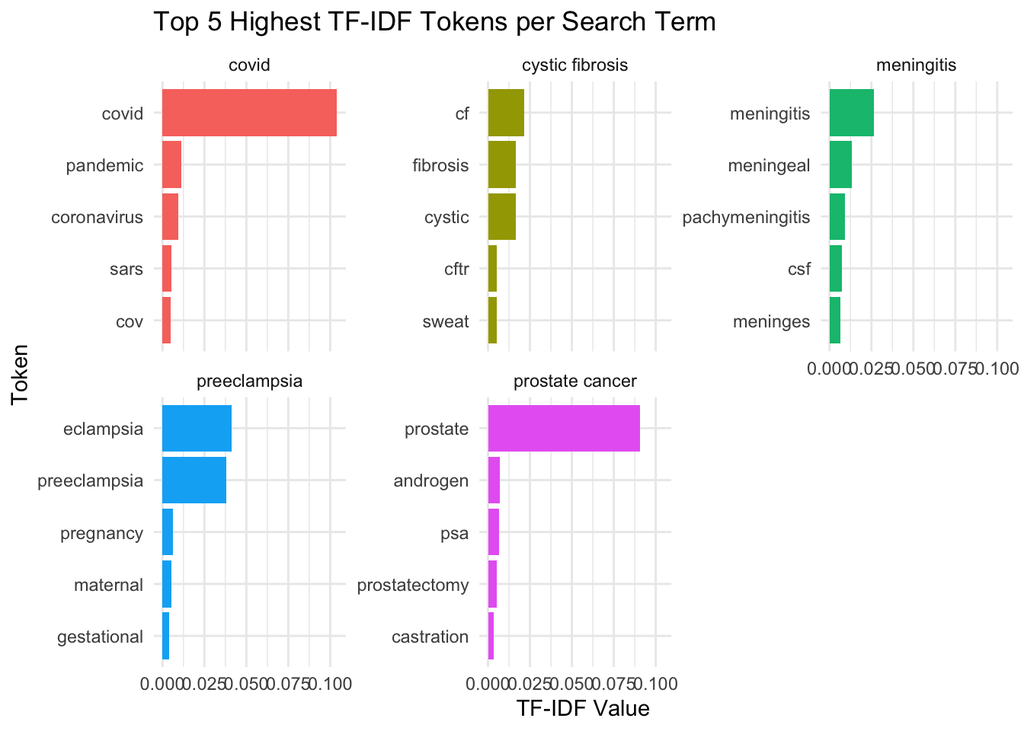

```r
# Visualization
top5_tfidf |>
  mutate(word = reorder_within(word, tf_idf, term)) |>
  ggplot(aes(x = word, y = tf_idf, fill = term)) +
  geom_col(show.legend = FALSE) +
  facet_wrap(~ term, scales = "free_y") +
  scale_x_reordered() +
  coord_flip() +
  labs(title = "Top 5 Highest TF-IDF Tokens per Search Term",
       x = "Token",
       y = "TF-IDF Value") +
  theme_minimal()
```

The 5 tokens from each search term with the highest TF-IDF value are:

- **covid**: covid, pandemic, coronavirus, sars, cov
- **cystic fibrosis**: cf, fibrosis, cystic, cftr, sweat
- **meningitis**: meningitis, meningeal, pachymeningitis, csf, meninges
- **preeclampsia**: eclampsia, preeclampsia, pregnancy, maternal, gestational
- **prostate cancer**: prostate, androgen, psa, prostatectomy, castration

*Observations*: The results are clearly different from the answers in Question 1. In Question 1, the most frequent words were more general while the TF-IDF emphasizes more topic-specific terminology that is unique to each search term. For instance, “sars” and “covid” were uniquely associated with covid-related abstracts, while “sweat” and “fibrosis” are distinctive in cystic fibrosis abstracts. This demonstrates that TF-IDF is more effective at isolating the terminology that characterizes each search term rather than words that are common across all medical abstracts.

# Sentiment Analysis

## Question 5

```r
# Sentiment analysis using the NRC lexicon
nrc <- get_sentiments("nrc")

sentiment_count <- tokens_clean |>
  inner_join(nrc) |>
  count(term, sentiment, sort = TRUE)

# Most common sentiment for each search term
top_sentiments <- sentiment_count |>
  group_by(term) |>
  slice_max(order_by = n, n = 1) |>
  ungroup()

top_sentiments |>
  kable(col.names = c("Term", "Sentiment", "Count"),
        caption = "Most Common Sentiment Per Search Term")
```

Most Common Sentiment Per Search Term

| Term | Sentiment | Count |
| --- | --- | --- |
| covid | positive | 9254 |
| cystic fibrosis | positive | 2564 |
| meningitis | negative | 1959 |
| preeclampsia | positive | 7603 |
| prostate cancer | negative | 8799 |

After performing a sentiment analysis using the NRC lexicon, the most common sentiment for each search term are as follows:

- **covid**: positive
- **cystic fibrosis**: positive
- **meningitis**: negative
- **preeclampsia**: positive
- **prostate cancer**: negative

```r
# Remove "positive" and "negative" from the list
sentiment_count |>
  filter(!sentiment %in% c("positive", "negative")) |>
  group_by(term) |>
  slice_max(order_by = n, n = 1) |>
  ungroup() |>
  kable(col.names = c("Term", "Sentiment", "Count"),
        caption = "Most Common Sentiment Per Search Term (After Removing 'Positive' and 'Negative'")
```

Most Common Sentiment Per Search Term (After Removing ‘Positive’ and ‘Negative’

| Term | Sentiment | Count |
| --- | --- | --- |
| covid | fear | 7373 |
| cystic fibrosis | disgust | 1714 |
| meningitis | fear | 1371 |
| preeclampsia | anticipation | 4555 |
| prostate cancer | fear | 8039 |

When removing “positive” and “negative” from the list, the most common sentiment changes to more specific emotions:

- **covid**: fear
- **cystic fibrosis**: disgust
- **meningitis**: fear
- **preeclampsia**: anticipation
- **prostate cancer**: fear

## Question 6

```r
# Sentiment analysis using AFINN lexicon
afinn <- get_sentiments("afinn")

afinn_sentiment <- pubmed |>
  mutate(abstract_id = row_number()) |>
  unnest_tokens(word, abstract) |>
  anti_join(stop_words, by = "word") |>
  inner_join(afinn) |>
  group_by(term, abstract_id) |>
  summarise(mean_sentiment = mean(value, na.rm = TRUE), .groups = "drop")
```

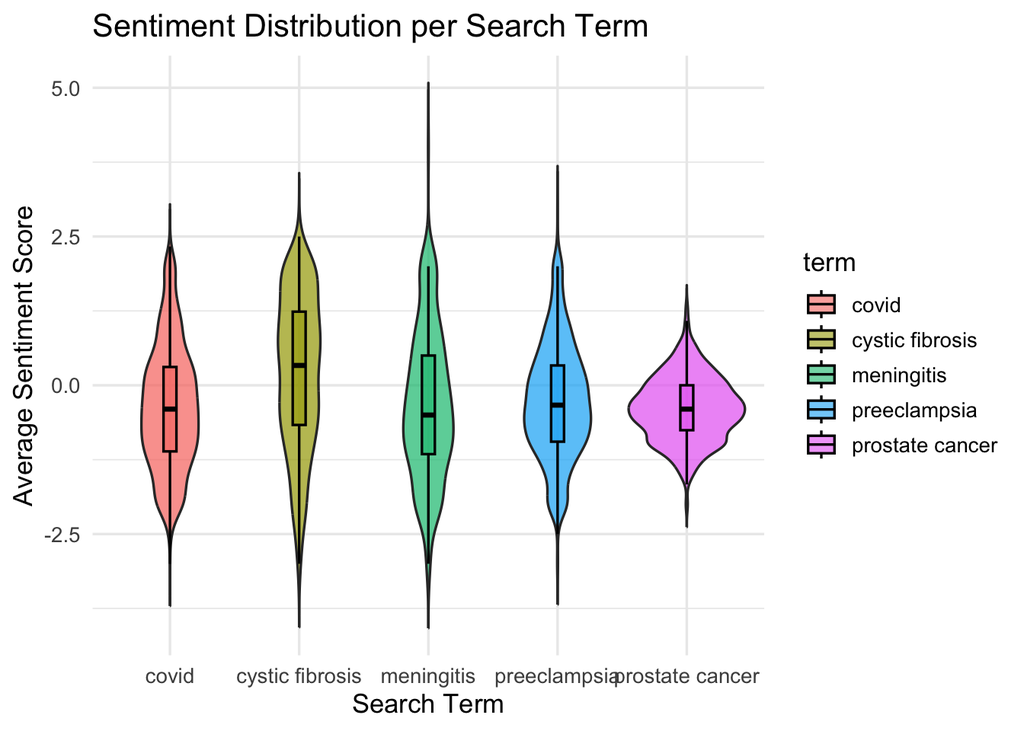

```r
# Visualization
afinn_sentiment |>
  ggplot(aes(x = term, y = mean_sentiment, fill = term)) +
  geom_violin(trim = FALSE, alpha = 0.7, show.legend = FALSE) +
  geom_boxplot(width = 0.1, color = "black", alpha = 0.6, outlier.shape = NA) +
  labs(title = "Sentiment Distribution per Search Term",
       x = "Search Term",
       y = "Average Sentiment Score") +
  theme_minimal(base_size = 13)
```

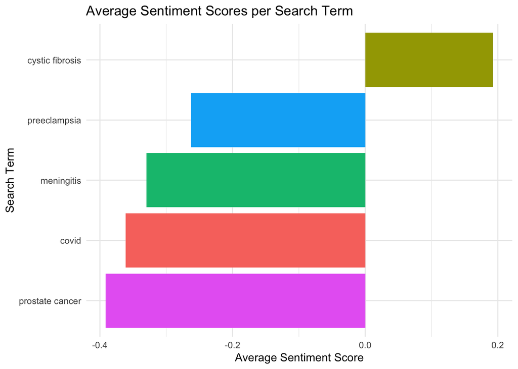

```r
afinn_sentiment |>
  group_by(term) |>
  summarise(avg_sentiment = mean(mean_sentiment, na.rm = TRUE)) |>
  ggplot(aes(x = reorder(term, avg_sentiment), y = avg_sentiment, fill = term)) +
  geom_col(show.legend = FALSE) +
  coord_flip() +
  labs(title = "Average Sentiment Scores per Search Term",
       x = "Search Term",
       y = "Average Sentiment Score") +
  theme_minimal()
```

*Interpretation*: After performing a sentiment analysis using the AFINN lexicon to get an average score for each abstract, the only term that had a positive score is cystic fibrosis while all the other search terms had negative sentiment scores. This is clearly noticeable in the bar plot but also in the violin plot, with the distribution for cystic fibrosis being wider towards the top. Meanwhile, the width of the other search terms are mostly the widest at values below 0, meaning their abstracts are more negative.

Back in Question 5, the most common sentiment from the NRC lexicon for cystic fibrosis was “positive”. After removing “positive” from the list, the most common sentiment for it was “disgust”. Given the outputs from Question 5, it arguably makes sense for cystic fibrosis to not be as negative compared to the other diseases. When looking up this disorder, the symptoms include persistent cough with thick mucus, wheezing, frequent lung infections, abdominal pain, sweat that tastes salty, and salty skin which can give off a “disgust” sentiment. Therefore, this disorder, compared to the other ones, is arguably less severe, which explains why it is the only search term with a positive sentiment score.